# Recurrence Quantification Analysis

# Data Exploration

This dataset originates from the traffic signal system, published via the Victoria (Australia) open transport data platform, and contains traffic volumes recorded every 15 minutes throughout March 2026 for multiple intersections. For this group project, we use the combined approach, where detector values are aggregated into a single total traffic volume per site at each timestamp. Detectors are individual sensors at an intersection, typically assigned to specific lanes or traffic movements, that count how many vehicles pass during each 15-minute interval. By summing these detector readings, we obtain a clean and consistent site level time series for analyzing temporal patterns and comparing traffic flow across sites.

```r
library(readr)
library(here)

library(ggplot2)

library(nonlinearTseries)

library(tseriesChaos)

library(crqa)
```

```r
traffic_data <- read_csv(here("data", "traffic_detectors_combined_100_161_164.csv"))
```

Below is a preview of the dataset. Each row represents a 15-minute interval at a specific site, where traffic volumes from all detectors have been aggregated into a single site-level measurement. The key variables are `site_total_volume`, which provides the traffic count and serves as the main time series for analysis, `timestamp`, which ensures the correct temporal order and regular spacing of observations, and `site_no`, which allows comparison of traffic dynamics across different intersections.

```r
head(traffic_data)
```

| timestamp | date | day_name | is_weekend | site_no | region | site_total_volume |
| --- | --- | --- | --- | --- | --- | --- |
| 2026-03-01 00:00:00 | 2026-03-01 | Sunday | TRUE | 100 | WV1 | 169 |
| 2026-03-01 00:00:00 | 2026-03-01 | Sunday | TRUE | 161 | WV1 | 241 |
| 2026-03-01 00:00:00 | 2026-03-01 | Sunday | TRUE | 164 | WV1 | 349 |
| 2026-03-01 00:15:00 | 2026-03-01 | Sunday | TRUE | 100 | WV1 | 111 |
| 2026-03-01 00:15:00 | 2026-03-01 | Sunday | TRUE | 161 | WV1 | 234 |
| 2026-03-01 00:15:00 | 2026-03-01 | Sunday | TRUE | 164 | WV1 | 316 |

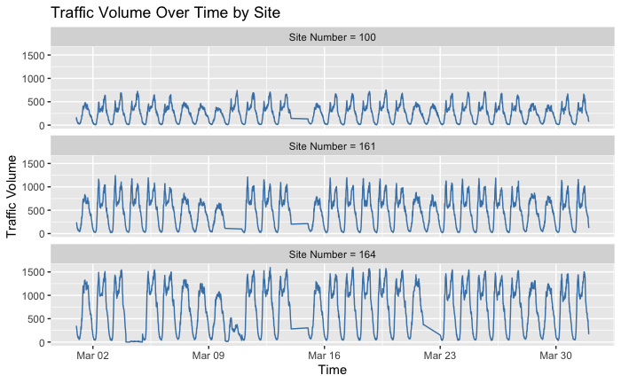

```r
ggplot(traffic_data, aes(x = timestamp, y = site_total_volume)) +
  geom_line(color = "steelblue") +
  facet_wrap(~ site_no, ncol = 1, labeller = labeller(site_no = function(x) paste("Site Number =", x))) +
  labs(
    title = "Traffic Volume Over Time by Site",
    x = "Time",
    y = "Traffic Volume"
  )
```

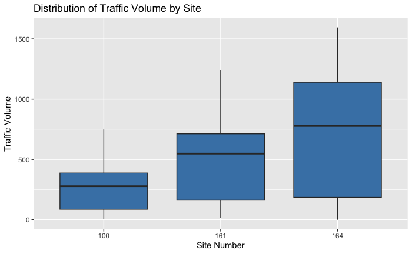

```r
ggplot(traffic_data, aes(x = factor(site_no), y = site_total_volume)) +
  geom_boxplot(fill = "steelblue") +
  labs(
    title = "Distribution of Traffic Volume by Site",
    x = "Site Number",
    y = "Traffic Volume"
  )
```

```r
by(traffic_data$site_total_volume, traffic_data$site_no, summary)
```

```
traffic_data$site_no: 100
   Min. 1st Qu.  Median    Mean 3rd Qu.    Max.
    5.0    87.0   278.0   266.3   387.0   749.0
---------------------------------------------------------------------------------------------------
traffic_data$site_no: 161
   Min. 1st Qu.  Median    Mean 3rd Qu.    Max.
   16.0   162.0   548.0   491.5   712.0  1242.0
---------------------------------------------------------------------------------------------------
traffic_data$site_no: 164
   Min. 1st Qu.  Median    Mean 3rd Qu.    Max.
    0.0   185.8   777.5   716.1  1139.2  1595.0
```

# RQA

## RQA - Single Site Analysis

Based on the data exploration, site 164 was selected for further analysis. This site exhibits the highest variability, with an interquartile range from 185.8 to 1139.2, as well as the highest median traffic volume (Mdn = 777.5), compared to site 161 (Mdn = 548.0) and site 100 (Mdn = 278.0). Furthermore, the observed temporal data exhibit a regularity, which is expected to result in meaningful recurrence patterns.

```r
# Select purely site 164 data
site164 <- traffic_data[traffic_data$site_no == 164, ]

# They should be ordered by just in case
site164 <- site164[order(site164$timestamp), ]

# Extract volumes
x <- site164$site_total_volume
```

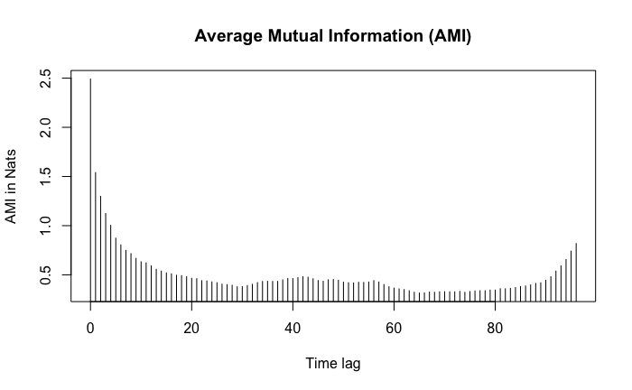

```r
x_scaled <- scale(x)[, 1]

ami <- mutualInformation(x_scaled, lag.max = 96, do.plot = TRUE)
```

```r
delay <- 29

# print(data.frame(lag = 0:96, ami = ami$mutual.information))
```

To estimate the delay parameter τ for RQA, Average Mutual Information (AMI) was computed for the scaled site 164 time series across lags 0 to 96. A maximum lag of 96 was chosen because each lag unit corresponds to one 15-minute interval, meaning 96 lags represents exactly one full day (96 × 15 = 1440 minutes). This ensures the AMI search spans a complete daily cycle.

The AMI curve dropped sharply after lag 0 and did not show an early local minimum. This pattern is likely caused by the difference between very low night-time traffic volumes and high daytime peaks, which makes smaller within day patterns less visible in the mutual information plot. The first local minimum occurred at lag 29 (AMI = 0.378), corresponding to approximately 7.25 hr. This time interval matches the approximate separation between the morning and evening traffic peaks, which are the two main recurring traffic states at site 164.

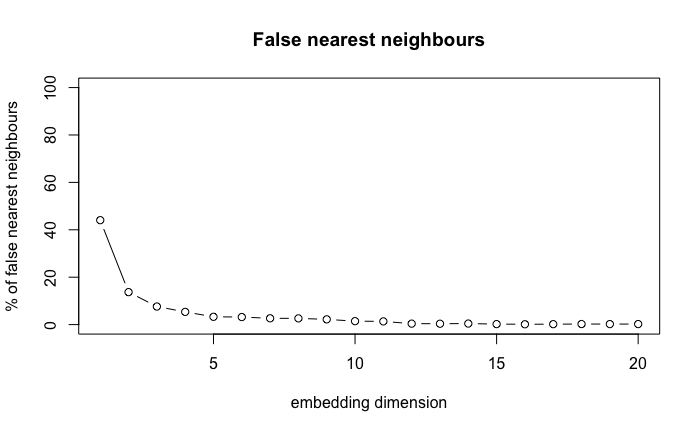

```r
# Embedding (m)
fnn <- false.nearest(x_scaled, m = 20, d = 29, t = 1, eps = sd(x_scaled))
plot(fnn)
```

```r
print(fnn)
```

```
                   m1           m2           m3           m4           m5           m6           m7           m8           m9
fraction 4.405679e-01 1.369773e-01 7.622807e-02 5.361154e-02 3.292085e-02 3.184526e-02 2.658207e-02 2.626588e-02 2.208446e-02
total    3.774932e+06 1.656128e+06 1.003646e+06 6.464280e+05 4.373520e+05 3.189800e+05 2.225560e+05 1.602840e+05 1.187260e+05
                  m10          m11          m12          m13          m14          m15          m16          m17          m18
fraction 1.451956e-02 1.351351e-02 4.042862e-03 3.664273e-03 4.429951e-03 2.127827e-03 1.472176e-03 1.853454e-03 2.367051e-03
total    8.650400e+04 6.704400e+04 5.095400e+04 4.039000e+04 3.250600e+04 2.537800e+04 2.037800e+04 1.618600e+04 1.267400e+04
                  m19          m20
fraction 2.195609e-03 2.266432e-03
total    1.002000e+04 7.942000e+03
```

```r
embed <- 5
```

The embedding dimension, M, was estimated using the False Nearest Neighbors (FNN) method. This method identifies how many delayed versions of the time series are needed to unfold the underlying system dynamics. The FNN fraction was calculated for embedding dimensions from 1 to 20, using the previously selected delay of τ = 29. The results showed a steep decrease from M = 1 (FNN = 44.0%) to M = 2 (FNN = 13.7%), followed by a slower decline at higher dimensions. After M = 5, where the FNN fraction reached 3.3%, further increases in embedding dimension produced only small improvements. Therefore, M = 5 was selected as a embedding dimension because it captures the main dynamics of the traffic system without adding unnecessary complexity.

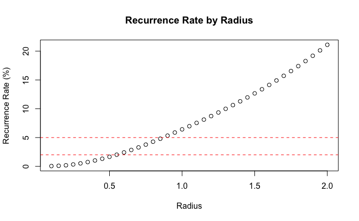

```r
# Radius (r)

radius_candidates <- seq(0.1, 2.0, by = 0.05)
rr_values <- numeric(length(radius_candidates))

for (i in seq_along(radius_candidates)) {
  result <- crqa(
    ts1         = x_scaled,
    ts2         = x_scaled,
    delay       = 29,
    embed       = 5,
    radius      = radius_candidates[i]
  )
  rr_values[i] <- result$RR
}

plot(radius_candidates, rr_values, type = "b", xlab = "Radius", ylab = "Recurrence Rate (%)", main = "Recurrence Rate by Radius")
abline(h = c(2, 5), col = "red", lty = 2)
```

```r
print(data.frame(radius = radius_candidates, RR = rr_values))
```

```
   radius          RR
1    0.10  0.05231642
2    0.15  0.09710287
3    0.20  0.18681626
4    0.25  0.33162766
5    0.30  0.51872490
6    0.35  0.74903515
7    0.40  1.02109740
8    0.45  1.32125654
9    0.50  1.65631202
10   0.55  2.02109403
11   0.60  2.41787839
12   0.65  2.84318111
13   0.70  3.29110183
14   0.75  3.77268262
```

[output cut: 25 more lines]

The radius parameter was selected by inspecting recurrence rates across a range of candidate radius values from 0.10 to 2.00, computed in steps of 0.05. For each candidate radius, a recurrence quantification analysis was run using the previously determined parameters of τ = 29 and M = 5, and the resulting recurrence rate was recorded.

Following the lecture guideline that continuous behavioral signals should ideally have a recurrence rate between 2% and 5%, with more deterministic signals placed closer to the lower end of this range, a radius of 0.55 was chosen. This radius produced a recurrence rate of 2.02%, indicating that the traffic volume time series at site 164 is highly structured and regular. This is consistent with its clear daily pattern, especially the repeated morning and evening traffic peaks.

```r
rqa_result <- crqa(
  ts1         = x_scaled,
  ts2         = x_scaled,
  delay       = 29,
  embed       = 5,
  rescale     = 0,
  radius      = 0.55,
  normalize   = 0,
  mindiagline = 2,
  minvertline = 2,
  tw          = 1,
  whiteline   = FALSE,
  recpt       = FALSE,
  side        = "both"
)

cat("RR:  ", rqa_result$RR,  "\n")
```

```
RR:   1.983613
```

```r
cat("DET: ", rqa_result$DET, "\n")
```

```
DET:  86.60179
```

```r
cat("L:   ", rqa_result$L,   "\n")
```

```
L:    5.72204
```

```r
cat("LAM: ", rqa_result$LAM, "\n")
```

```
LAM:  91.71872
```

```r
cat("TT:  ", rqa_result$TT,  "\n")
```

```
TT:   4.033544
```

```r
cat("ENTR:", rqa_result$ENTR,"\n")
```

```
ENTR: 2.114242
```

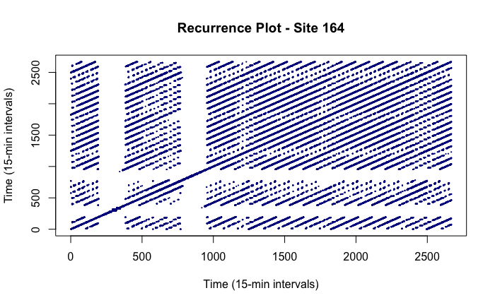

```r
RP <- matrix(as.numeric(rqa_result$RP), nrow = nrow(rqa_result$RP))

plot(NULL, xlim = c(1, ncol(RP)), ylim = c(1, nrow(RP)),
     xlab = "Time (15-min intervals)",
     ylab = "Time (15-min intervals)",
     main = "Recurrence Plot - Site 164")

for (l in 1:ncol(RP)) {
  ind <- which(RP[, l] == 1)
  points(rep(l, length(ind)), ind,
         cex = 0.3,
         col = "blue4",
         pch = 16)
}
```